# Analysis of Pierce County House Sales

Henry Shaw & Saransh Rakshak

Due: September 3rd, 2024

Below is a breakdown of four variables selected within the Pierce County House Sales dataset provided. We decided to choose House Square Feet, Bedrooms, Bathrooms, and Year Built for our four fields to review.

Correlation of Variables with Sale Price - Entire Dataset

|  | sale_price | house_square_feet | year_built | bedrooms | bathrooms |
| --- | --- | --- | --- | --- | --- |
| Correlation | 1 | 0.5263257 | 0.4094384 | 0.2288812 | 0.2054946 |

- When we break down the correlation analysis to just the houses under $1,000,000 subset, we can see all four variables increase in their correlation to sales price. This can be seen below:

Correlation of Variables with Sale Price - Under $1,000,000

|  | sale_price | house_square_feet | year_built | bedrooms | bathrooms |
| --- | --- | --- | --- | --- | --- |
| Correlation | 1 | 0.6277807 | 0.505363 | 0.3415674 | 0.3223927 |

- When we break down the correlation analysis to just the houses over $1,000,000 subset, we can see the chosen variables decrease in their correlation to sales price. House Square Feet and Bathrooms have a negative correlation now. This can be seen below:

Correlation of Variables with Sale Price - Over $1,000,000

|  | sale_price | house_square_feet | year_built | bedrooms | bathrooms |
| --- | --- | --- | --- | --- | --- |
| Correlation | 1 | -0.1650727 | 0.0623177 | 0.0444497 | -0.0398135 |

### Histogram for House Square Feet with Sales Price under $1,000,000.

For our variable that shows the highest correlation to sales price, we decided to plot a histogram for House Square Feet.

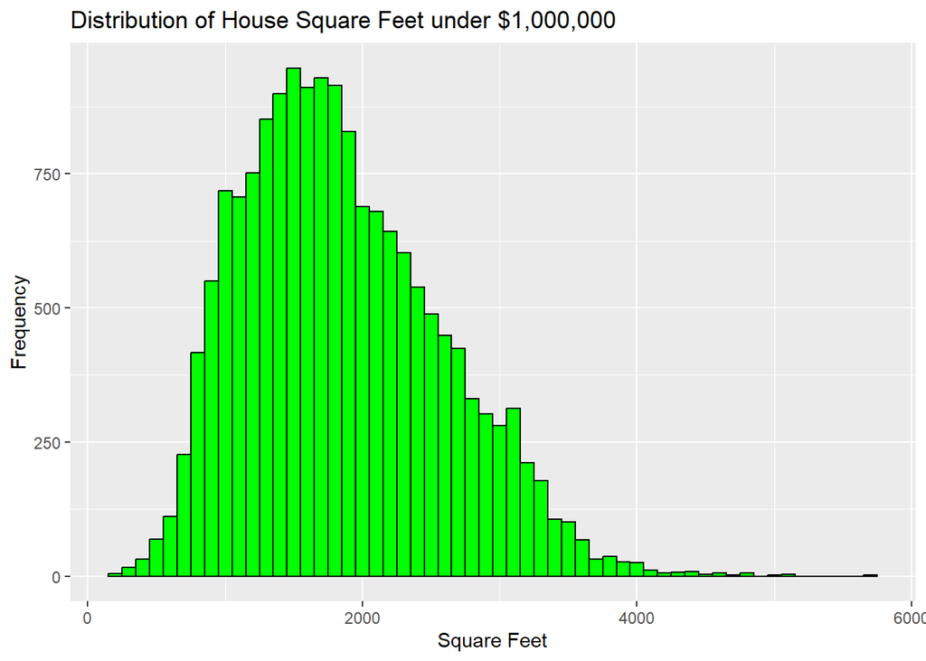

Summary Statistics of House Square Feet under $1,000,000

| Mean Square Feet | Median Square Feet | SD of Square Feet | Min Square Feet | Max Square Feet |
| --- | --- | --- | --- | --- |
| 1,855 | 1,761 | 722 | 200 | 5,700 |

Additional Summary Statistics of House Square Feet under $1,000,000

| SD of Square Feet | Range | IQR | Skewness | Kurtosis |
| --- | --- | --- | --- | --- |
| 722.46 | 5500.00 | 1009.00 | 0.57 | 0.08 |

- The histogram for House Square Feet under $1,000,000 is positively or rightly skewed. This can be seen off in the visual and the summary statistics as well. With the median at 1,761, this square feet amount is closer to the min (200) than the max (5,700) which alights with the right skewness of the histogram. This is supported by the skewness value greater than 0.
- Majority of the homes fall closer to the mean, which can be seen with more bars towards the left. The longer tail to the right shows multiple outliers of houses under $1,000,000 that have a higher total of square feet.

### Histogram for House Square Feet with Sales Price over $1,000,000.

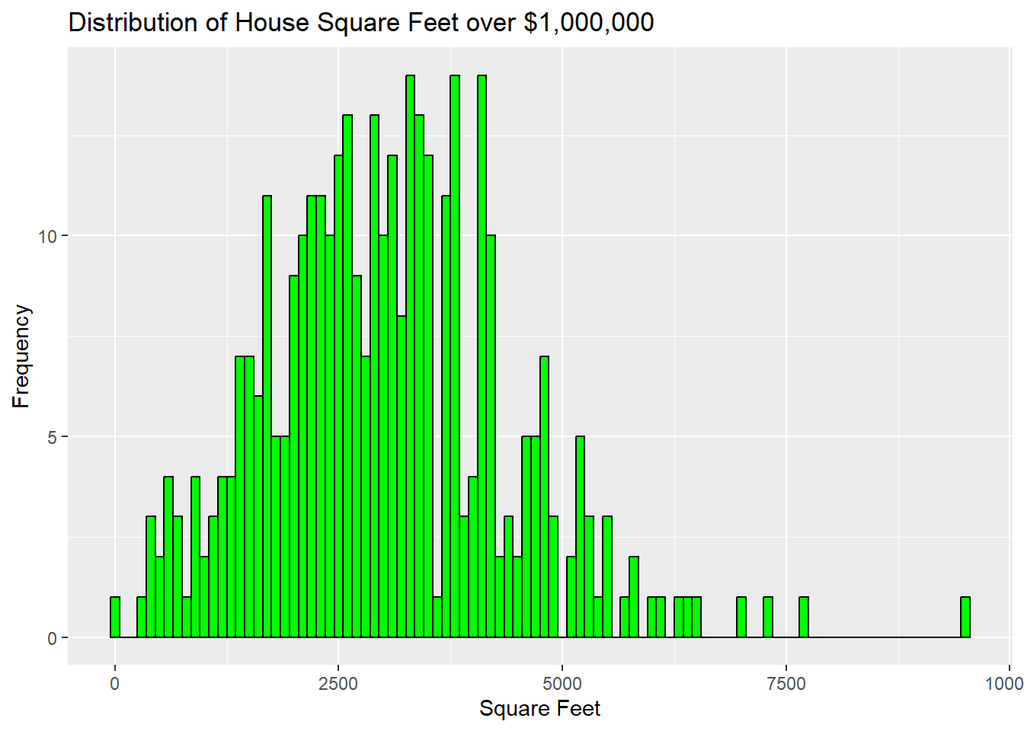

Summary Statistics of House Square Feet over $1,000,000

| Mean Square Feet | Median Square Feet | SD of Square Feet | Min Square Feet | Max Square Feet |
| --- | --- | --- | --- | --- |
| 3,027 | 2,964 | 1,354 | 1 | 9,510 |

Additional Summary Statistics of House Square Feet over $1,000,000

| SD of Square Feet | Range | IQR | Skewness | Kurtosis |
| --- | --- | --- | --- | --- |
| 1354.11 | 9509.00 | 1714.00 | 0.64 | 1.35 |

### Boxplot for Bedrooms with Sales Price under $1,000,000.

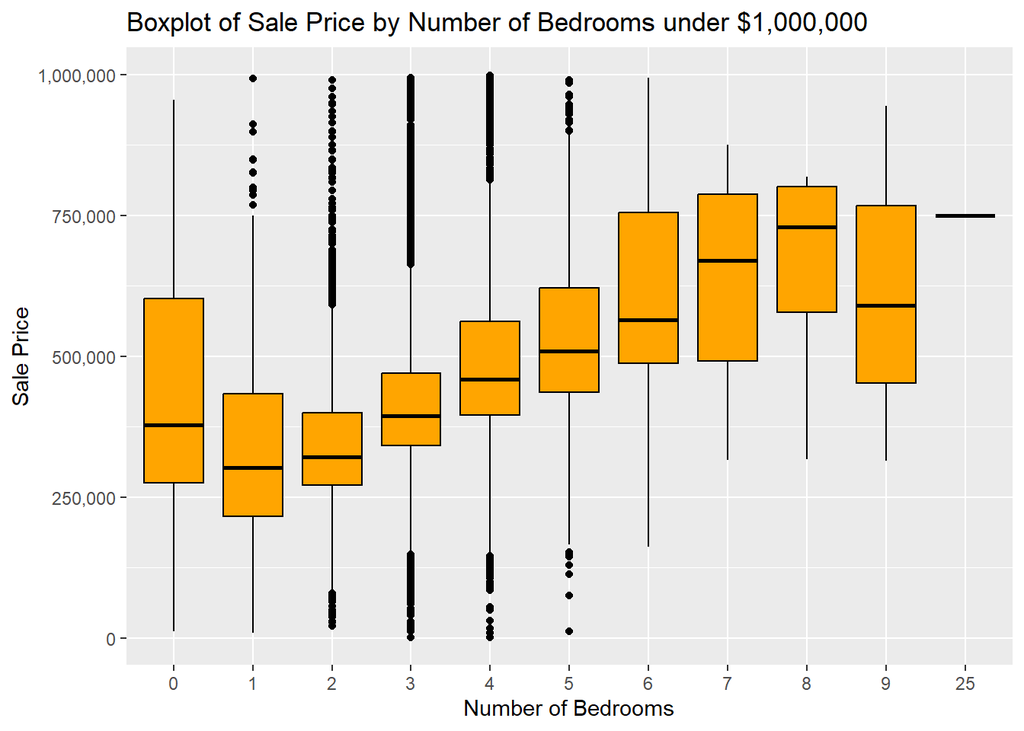

Summary Statistics for Sale Price by Number of Bedrooms under $1,000,000

| Bedrooms | Count | Mean Sale Price | Median Sale Price | SD of Sale Price | Min Sale Price | Max Sale Price |
| --- | --- | --- | --- | --- | --- | --- |
| 0 | 43 | 432,784 | 378,000 | 216,403 | 12,510 | 955,000 |
| 1 | 322 | 344,803 | 302,125 | 190,263 | 10,000 | 992,500 |
| 2 | 1867 | 352,671 | 322,000 | 147,424 | 22,000 | 990,000 |
| 3 | 8371 | 420,669 | 395,000 | 138,850 | 2,000 | 995,000 |
| 4 | 4727 | 488,858 | 460,000 | 146,688 | 2,000 | 999,000 |
| 5 | 996 | 532,524 | 508,950 | 148,665 | 12,752 | 990,000 |
| 6 | 105 | 597,389 | 565,000 | 182,267 | 162,000 | 994,990 |
| 7 | 18 | 637,309 | 669,500 | 172,348 | 316,000 | 875,990 |
| 8 | 4 | 649,038 | 730,000 | 231,370 | 317,150 | 819,000 |
| 9 | 3 | 616,300 | 590,000 | 315,274 | 315,000 | 943,900 |
| 25 | 1 | 749,950 | 749,950 | NA | 749,950 | 749,950 |

### Boxplot for Bedrooms with Sales Price over $1,000,000.

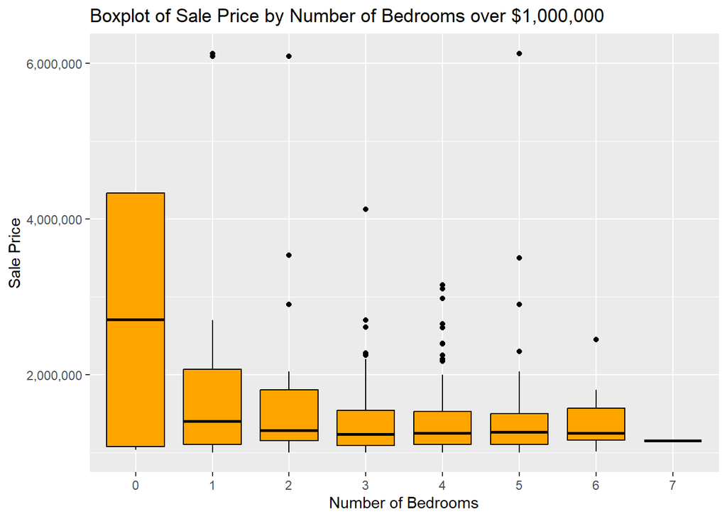

Summary Statistics for Sale Price by Number of Bedrooms over $1,000,000

| Bedrooms | Count | Mean Sale Price | Median Sale Price | SD of Sale Price | Min Sale Price | Max Sale Price |
| --- | --- | --- | --- | --- | --- | --- |
| 0 | 4 | 2,696,050 | 2,710,050 | 1,891,595 | 1,030,000 | 4,334,100 |
| 1 | 15 | 2,119,367 | 1,400,000 | 1,695,763 | 1,000,000 | 6,130,000 |
| 2 | 33 | 1,633,679 | 1,280,000 | 969,146 | 1,000,000 | 6,090,000 |
| 3 | 133 | 1,376,480 | 1,236,000 | 425,868 | 1,000,000 | 4,126,500 |
| 4 | 131 | 1,390,515 | 1,250,000 | 437,610 | 1,000,000 | 3,150,000 |
| 5 | 32 | 1,584,058 | 1,262,500 | 997,557 | 1,000,000 | 6,130,000 |
| 6 | 8 | 1,439,011 | 1,245,000 | 478,487 | 1,012,000 | 2,450,000 |
| 7 | 1 | 1,147,500 | 1,147,500 | NA | 1,147,500 | 1,147,500 |

### Boxplot for Bathrooms with Sales Price under $1,000,000.

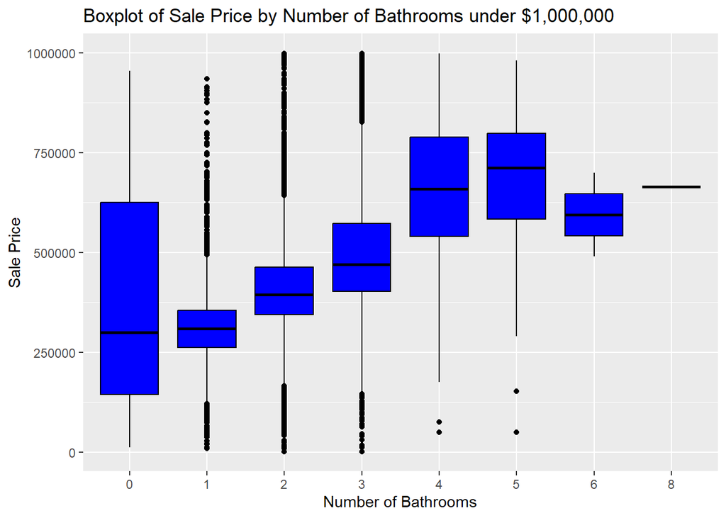

Summary Statistics for Sale Price by Number of Bathrooms under $1,000,000

| Bathrooms | Count | Mean Sale Price | Median Sale Price | SD of Sale Price | Min Sale Price | Max Sale Price |
| --- | --- | --- | --- | --- | --- | --- |
| 0 | 29 | 361,673 | 300,000 | 266,487 | 12,510 | 955,000 |
| 1 | 2911 | 314,366 | 310,000 | 108,335 | 10,000 | 935,000 |
| 2 | 6272 | 413,864 | 394,995 | 125,594 | 2,000 | 999,000 |
| 3 | 6667 | 498,966 | 469,950 | 141,462 | 2,000 | 998,950 |
| 4 | 529 | 659,695 | 659,999 | 167,920 | 50,000 | 998,000 |
| 5 | 46 | 680,490 | 711,571 | 212,168 | 50,412 | 980,500 |
| 6 | 2 | 594,975 | 594,975 | 148,528 | 489,950 | 700,000 |
| 8 | 1 | 665,000 | 665,000 | NA | 665,000 | 665,000 |

- For bathrooms, there are eight total unique variables. The majority of the population falls between 1 to 4 bathrooms with 16,379 houses.
- This boxplot shows that as the number of bathrooms increases, so does the average sales price of the household. This can be seen starting with 1-bathroom houses ($314,366) with a consistent increase in the mean to 5-bathroom houses ($680,490).
- The 8-bathroom house is an outlier as the number of bedrooms increases by one until it jumps from 6 to 8. Additionally, the 6-bathroom houses are outliers as they only contain two instances within the subset under $1,000,000.

### Boxplot for Bathrooms with Sales Price over $1,000,000.

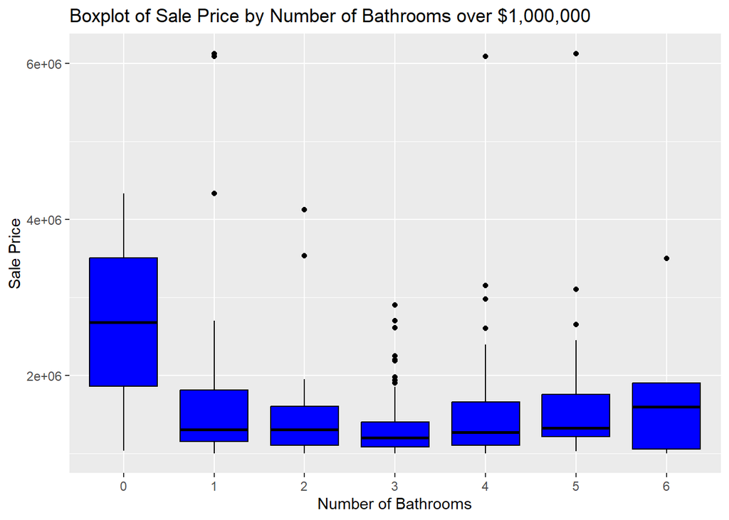

Summary Statistics for Sale Price by Number of Bathrooms over $1,000,000

| Bathrooms | Count | Mean Sale Price | Median Sale Price | SD of Sale Price | Min Sale Price | Max Sale Price |
| --- | --- | --- | --- | --- | --- | --- |
| 0 | 2 | 2,682,050 | 2,682,050 | 2,336,352 | 1,030,000 | 4,334,100 |
| 1 | 29 | 1,868,691 | 1,299,999 | 1,352,795 | 1,000,000 | 6,130,000 |
| 2 | 41 | 1,459,376 | 1,300,000 | 613,340 | 1,000,000 | 4,126,500 |
| 3 | 149 | 1,323,784 | 1,200,000 | 376,659 | 1,000,000 | 2,900,000 |
| 4 | 104 | 1,465,920 | 1,267,500 | 626,738 | 1,000,000 | 6,090,000 |
| 5 | 27 | 1,738,251 | 1,322,500 | 1,027,935 | 1,025,000 | 6,130,000 |
| 6 | 5 | 1,808,400 | 1,592,000 | 1,018,014 | 1,000,000 | 3,500,000 |

- Unlike houses that are sold for under $1M, for sales over $1M, there are an extremely small amount of purchases for properties with no bathrooms. This again can be explained by the client purchasing an undeveloped area of land which may have no bedrooms or bathrooms. Also, sales price stays relatively constant even with the addition of bathrooms, showing that the amount of bathrooms in a house may not be a big factors for home-seekers willing to pay over $1M.

### Histogram for Year Built with Sales Price under $1,000,000.

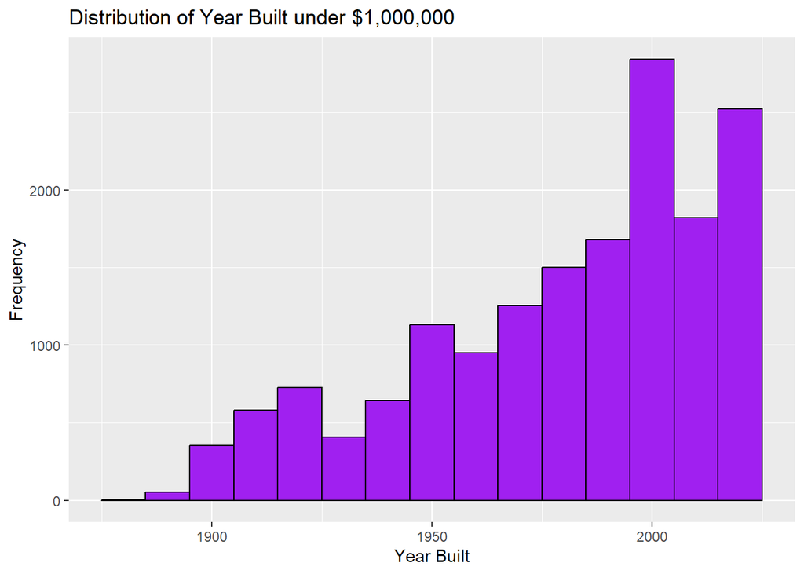

Summary Statistics of Year Built under $1,000,000

| Mean Year Built | Median Year Built | Min Year Built | Max Year Built |
| --- | --- | --- | --- |
| 1980.402 | 1990 | 1880 | 2021 |

Additional Summary Statistics of Year Built under $1,000,000

| SD of Year Built | Range | IQR | Skewness | Kurtosis |
| --- | --- | --- | --- | --- |
| 33.43 | 141.00 | 48.00 | -0.77 | -0.42 |

- The histogram for Year Built under $1,000,000 is negatively or left skewed. This can be seen off in the visual and the summary statistics as well. With the median year of 1990, this year is closer to the max (2021) than the min (1880) which aligns with the left skewness of the histogram. This is supported by the skewness value less than 0 of -0.77.
- Majority of the homes fall closer to the mean, which can be seen with more bars towards the right. The longer tail to the left shows multiple outliers of houses under $1,000,000 that have a lower date built.

### Histogram for Year Built with Sales Price over $1,000,000.

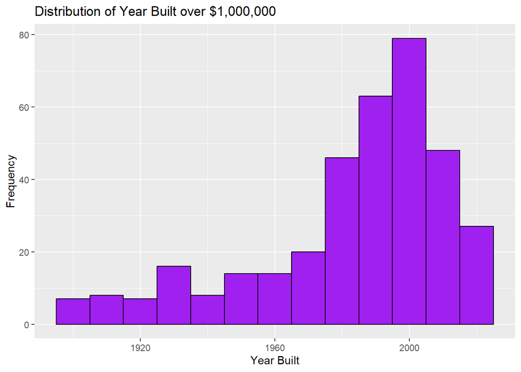

Summary Statistics of Year Built over $1,000,000

| Mean Year Built | Median Year Built | Min Year Built | Max Year Built |
| --- | --- | --- | --- |
| 1983.571 | 1991 | 1900 | 2021 |

Additional Summary Statistics of Year Built over $1,000,000

| SD of Year Built | Range | IQR | Skewness | Kurtosis |
| --- | --- | --- | --- | --- |
| 28.93 | 121.00 | 30.00 | -1.18 | 0.65 |

- Similar to houses under $1M, our distribution is left-skewed, showing that regardless of purchasing budgets, home-seekers prefer to purchase newly developed housing.

#### Grid of all Plots under $1,000,000

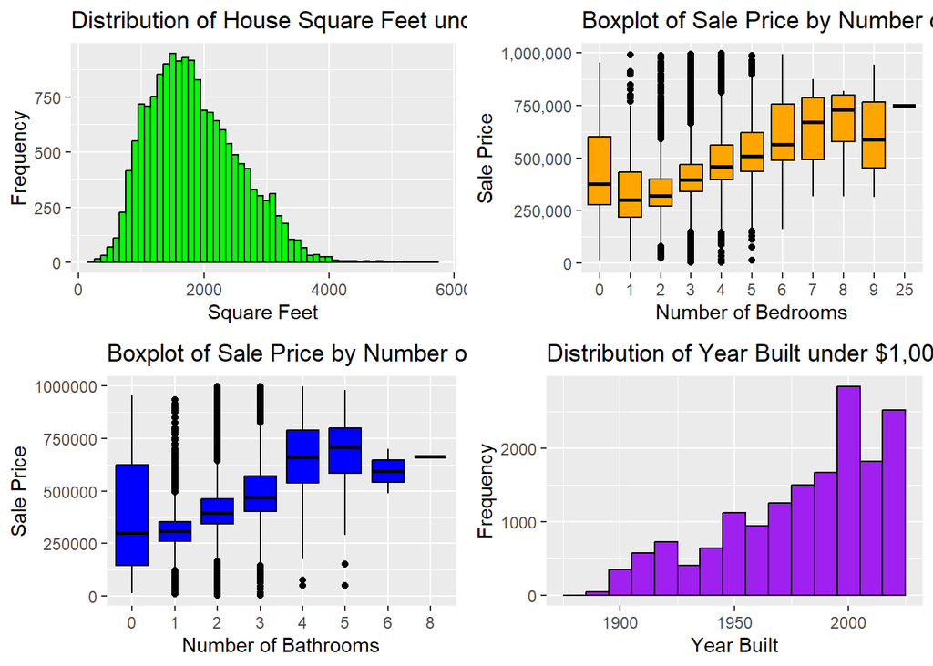

#### Grid of all Plots over $1,000,000

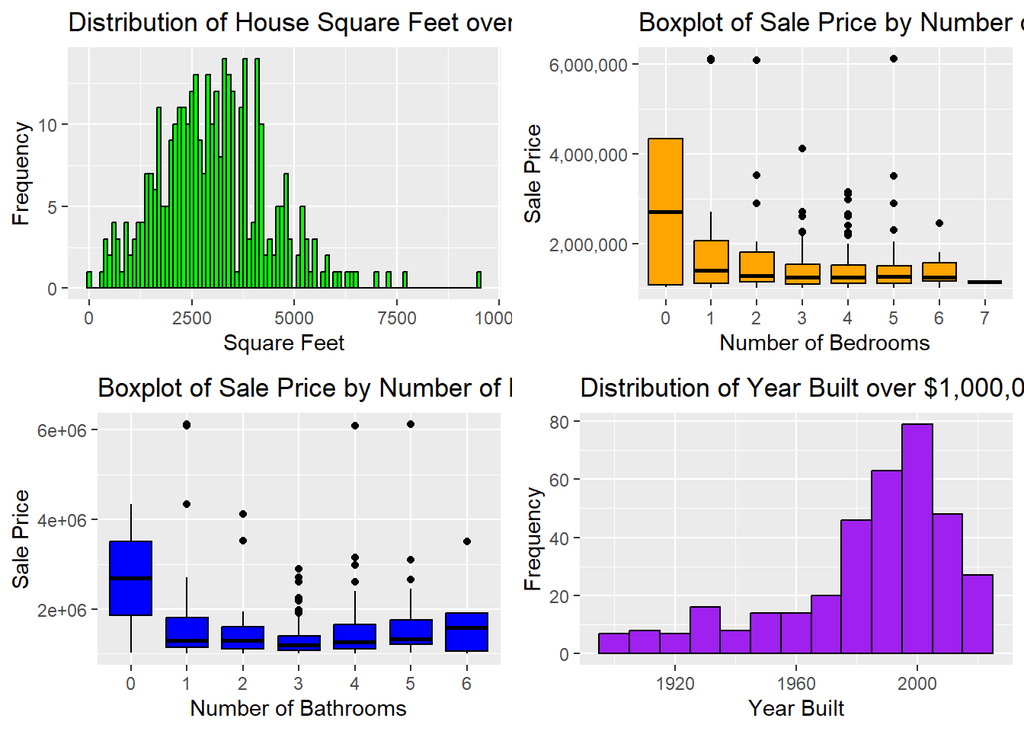